# Homework 1 ID3 Decision Tree

Matthew Jensen

2024-09-14

# Part 1

## Problem 1.a

### Split 1

#### Step 1.ii Information Gain for Each Attribute

The formula for Information Gain is:

$$\text{Information Gain} = IG(S, A) = H(S) - \sum_{v \in
\text{Values}(A)} \frac{|S_v|}{|S|} H(S_v)$$

##### **$x_1$** :

For the given proportions and entropy calculations:

When $x_1 = 0$, the proportions are: - Proportion of $y = 1$ is $\frac{1}{5}$ - Proportion of $y = 0$ is $\frac{4}{5}$

Entropy for $x_1 = 0$ is:

$$H(Y_{x_1 = 0}) = - \left( \frac{4}{5} \log_2 \left(\frac{4}{5}\right) +
\frac{1}{5} \log_2 \left(\frac{1}{5}\right) \right) \approx 0.7219$$

When $x_1 = 1$, the proportions are: * Proportion of $y = 1$ is $\frac{1}{2}$ * Proportion of $y = 0$ is $\frac{1}{2}$

Entropy for $x_1 = 1$ is:

$$H(Y_{x_1 = 1}) = - \left( \frac{1}{2} \log_2 \left(\frac{1}{2}\right) +
\frac{1}{2} \log_2 \left(\frac{1}{2}\right) \right) = 1$$

Information Gain for $x_1$ is:

##### **$x_2$** :

When $x_2 = 0$, the proportions are: - Proportion of $y = 1$ is $\frac{2}{3}$ - Proportion of $y = 0$ is $\frac{1}{3}$

Entropy for $x_2 = 1$ is:

$$H(Y_{x_2 = 1}) = - \left( \frac{4}{4} \log_2 \left(\frac{4}{4}\right) +
\frac{0}{4} \log_2 \left(\frac{0}{4}\right) \right) = 0$$
Information Gain for $x_2$ is:

$$IG(Y, x_2) = H(Y) - \left( \frac{3}{7} H(Y_{x_2 = 0}) + \frac{4}{7}
H(Y_{x_2 = 1}) \right)$$
$$IG(x_2)= 0.862−0.393= 0.469$$

##### **$x_3$** :

When $x_3 = 0$, the proportions are: - Proportion of $y = 1$ is $\frac{1}{4}$ - Proportion of $y = 0$ is $\frac{3}{4}$

Entropy for $x_3 = 0$ is:

$$H(Y_{x_3 = 0}) = - \left( \frac{1}{4} \log_2 \left(\frac{1}{4}\right) +
\frac{3}{4} \log_2 \left(\frac{3}{4}\right) \right) \approx .8113$$
When $x_3 = 0$, the proportions are: - Proportion of $y = 1$ is $\frac{1}{4}$ - Proportion of $y = 0$ is $\frac{3}{4}$

Entropy for $x_3 = 0$ is:

$$H(Y_{x_3 = 0}) = - \left( \frac{1}{4} \log_2 \left(\frac{1}{4}\right) +
\frac{3}{4} \log_2 \left(\frac{3}{4}\right) \right) \approx 0.811$$
When $x_3 = 1$, the proportions are: * Proportion of $y = 1$ is $\frac{1}{3}$ * Proportion of $y = 0$ is $\frac{2}{3}$

Entropy for $x_3 = 1$ is:

$$H(Y_{x_3 = 1}) = - \left( \frac{1}{3} \log_2 \left(\frac{1}{3}\right) +
\frac{2}{3} \log_2 \left(\frac{2}{3}\right) \right) \approx 0.918$$
Information Gain for $x_3$ is:

$$IG(Y, x_3) = H(Y) - \left( \frac{4}{7} H(Y_{x_3 = 0}) + \frac{3}{7}
H(Y_{x_3 = 1}) \right)$$
$$IG(x_3)= 0.862−0.856= 0.006$$

##### **$x_4$** :

When $x_4 = 0$, the proportions are: - Proportion of $y = 1$ is $\frac{0}{4}$ - Proportion of $y = 0$ is $\frac{4}{4}$

Entropy for $x_4 = 0$ is:

$$H(Y_{x_4 = 0}) = - \left( \frac{0}{4} \log_2 \left(\frac{0}{4}\right) +
\frac{4}{4} \log_2 \left(\frac{4}{4}\right) \right) = 0$$
When $x_4 = 1$, the proportions are: * Proportion of $y = 1$ is $\frac{2}{3}$ * Proportion of $y = 0$ is $\frac{1}{3}$

Entropy for $x_4 = 1$ is:

$$H(Y_{x_4 = 1}) = - \left( \frac{2}{3} \log_2 \left(\frac{2}{3}\right) +
\frac{1}{3} \log_2 \left(\frac{1}{3}\right) \right) \approx 0.918$$
Information Gain for $x_4$ is:

$$IG(Y, x_4) = H(Y) - \left( \frac{4}{7} H(Y_{x_4 = 0}) + \frac{3}{7}
H(Y_{x_4 = 1}) \right)$$
$$IG(x_4)= 0.862−0.393= 0.469$$

## Split 2.1 - Left Side of Tree

### Step 2.i Entropy Calculation

We know will split the dataset on $x_2$

Dataset when $x_2$ = 0

Let’s start with the table $x_2$ = 0

$$\begin{array}{|c|c|c|c|c|}
\hline
x_1 & x_2 & x_3 & x_4 & y \\
\hline
0 & 0 & 1 & 0 & 0 \\
0 & 0 & 1 & 1 & 1 \\
1 & 0 & 0 & 1 & 1 \\
\hline
\end{array}$$

When $x_2 = 0$, the proportions are: * Proportion of $y = 1$ is $\frac{2}{3}$ * Proportion of $y = 0$ is $\frac{1}{3}$

Entropy for Y|$x_2 = 0$ =
$$-(\frac{2}{3} \cdot \log_2(\frac{2}{3}) + \frac{1}{3} \cdot
\log_2(\frac{1}{3})) = .9183$$

### Step 2.ii Information Gain for Each Attribute

#### **$x_1 | x_2 = 0$** :

When $x_1 = 0 | x_2 = 0$, the proportions are: - Proportion of $y = 1$ is $\frac{1}{2}$ - Proportion of $y = 0$ is $\frac{1}{2}$

Entropy for $x_1 = 0 | x_2 = 0$ is:

$$H(Y_{x_1 = 0 | x_2 = 1}) = - \left( \frac{1}{2} \log_2
\left(\frac{1}{2}\right) + \frac{1}{2} \log_2 \left(\frac{1}{2}\right)
\right) = 1$$

When $x_1 = 1 | x_2 =0$, the proportions are: * Proportion of $y = 1$ is $\frac{1}{1}$ * Proportion of $y = 0$ is $\frac{0}{1}$

Entropy for $x_1 = 1 | x_2 = 0$ is:

$$H(Y_{x_1 = 1 | x_2 = 0}) = - \left( \frac{1}{1} \log_2
\left(\frac{1}{1}\right) + \frac{0}{1} \log_2 \left(\frac{1}{1}\right)
\right) = 0$$

Information Gain for $x_1 | x_2 = 0$ is:

$$IG(Y, x_1 | x_2 = 0) = H(Y|x_2 =0) - \left( \frac{2}{3} H(Y_{x_1 = 0|
x2=0}) + \frac{1}{3} H(Y_{x_1 = 1| x_2 = 0}) \right)$$
$$IG(Y, x_1 | x_2 = 0) = .9183 - \left( \frac{2}{3} \cdot 1 + \frac{1}{3}
\cdot 0 \right) \approx 0.252$$

#### **$x_3 | x_2 = 0$** :

For the given proportions and entropy calculations:

When $x_3 = 0 | x_2 = 0$, the proportions are: - Proportion of $y = 1$ is $\frac{1}{1}$ - Proportion of $y = 0$ is $\frac{0}{1}$

Entropy for $x_3 = 0 | x_2 = 0$ is:

Entropy for $x_3 = 1 | x_2 = 0$ is:

$$H(Y_{x_3 = 1 | x_2 = 0}) = - \left( \frac{1}{2} \log_2
\left(\frac{1}{2}\right) + \frac{1}{2} \log_2 \left(\frac{1}{2}\right)
\right) = 1$$
Information Gain for $x_1 | x_2 = 0$ is:

$$IG(Y, x_3 | x_2 = 0) = H(Y|x_2 =0) - \left( \frac{2}{3} H(Y_{x_3 = 0|
x2=0}) + \frac{1}{3} H(Y_{x_3 = 1| x_2 = 0}) \right)$$
$$IG(Y, x_3 | x_2 = 0) = .9183 - \left( \frac{2}{3} \cdot 1 + \frac{1}{3}
\cdot 0 \right) \approx 0.252$$

#### **( x_4 | x2= 0)** :

For the given proportions and entropy calculations:

When $x_4 = 0 | x_2 = 0$, the proportions are: - Proportion of $y = 1$ is $\frac{0}{1}$ - Proportion of $y = 0$ is $\frac{1}{1}$

Entropy for $x_4 = 0 | x_2 = 0$ is:

0

When $x_4 = 1 | x_2 = 0$, the proportions are: - Proportion of $y = 1$ is $\frac{1}{1}$ - Proportion of $y = 0$ is $\frac{0}{1}$

Entropy for $x_4 = 1 | x_2 = 0$ is:

0

Information Gain for ( x_4 | x_2 =0 ) is :

.918 - 0 = .918

**Thus $x_4$ has the highest Information Gain and will be the next split. Because the node is pure, we can make leaf nodes where if x_4 = 0 then y = 0 and if x_4 = 1 then y=1}**

## Split 2.2 Right side of the tree.

We will now go back and look at the case when x_2 = 1.

ataset when $x_2$ = 1

$$\begin{array}{|c|c|c|c|c|}
\hline
x_1 & x_2 & x_3 & x_4 & y \\
\hline
0 & 1 & 0 & 0 & 0 \\
0 & 1 & 1 & 0 & 0 \\
1 & 1 & 0 & 0 & 0 \\
0 & 1 & 0 & 1 & 0 \\
\hline
\end{array}$$

When $x_2 = 1$, the proportions are: * Proportion of $y = 1$ is $\frac{0}{4}$ * Proportion of $y = 0$ is $\frac{4}{4}$

Entropy for Y|$x_2 = 0$ =
$$-(\frac{4}{4} \cdot \log_2(\frac{4}{4}) + \frac{0}{4} \cdot
\log_2(\frac{0}{4})) = 0$$

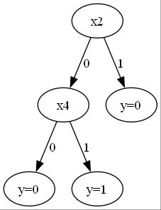

**Picture of Final Decision Tree**

## Problem 1.b Boolean Function Table

$$\begin{array}{|c|c|c|c|c|}
\hline
x_1 & x_2 & x_3 & x_4 & y \\
\hline
- & 0 & - & 0 & 0 \\
- & 0 & - & 1 & 1 \\
- & 1 & - & - & 0 \\
\hline
\end{array}$$

If $x_2 = 0$ and $x_4 = 0$ then $y = 0$, If $x_2 = 0$ and $x_4 = 1$ then $y = 1$, If $x_2 = 1$ then $y = 0$

# Problem 2

## 2.a Majority Error on Play Tennis Dataset

$$\begin{array}{|c|c|c|c|c|}
\hline
\text{Outlook} & \text{Temperature} & \text{Humidity} &
\text{Wind} & \text{PlayTennis} \\
\hline
\text{S} & \text{H} & \text{H} & \text{W} & - \\
\text{S} & \text{H} & \text{H} & \text{S} & - \\
\text{O} & \text{H} & \text{H} & \text{W} & + \\
\text{R} & \text{M} & \text{H} & \text{W} & + \\
\text{R} & \text{C} & \text{N} & \text{W} & + \\
\text{R} & \text{C} & \text{N} & \text{S} & - \\
\text{O} & \text{C} & \text{N} & \text{S} & + \\
\text{S} & \text{M} & \text{H} & \text{W} & - \\
\text{S} & \text{C} & \text{N} & \text{W} & + \\
\text{R} & \text{M} & \text{N} & \text{W} & + \\
\text{S} & \text{M} & \text{N} & \text{S} & + \\
\text{O} & \text{M} & \text{H} & \text{S} & + \\
\text{O} & \text{H} & \text{N} & \text{W} & + \\
\text{R} & \text{M} & \text{H} & \text{S} & - \\
\hline
\end{array}$$

### Step i. Calculate the Majority Error of Data Set

$$ME(S) = 1 - \max(p_+,p_-)$$
In dataset, the proportion of positives is $\frac{9}{14}$ and the proporiton of negatives is $\frac{5}{14}$

Thus the majority error is 1 - $\frac{9}{14}$ = $\frac{5}{14}$ = .3571

### Step ii. Calculate the ME for each attribute

#### **Outlook**

When Outlook = Sunny, PlayTennis = [-,-,-,+,+] ME(Outlook = Sunny) = 1 - $\frac{3}{5}$ = $\frac{2}{5}$

When Outlook = Overcast, PlayTennis = [+,+,+,+] ME(Outlook = Overcast) = 1 - $\frac{4}{4}$ = 0

When Outlook = Rainy, PlayTennis = [+,+,-,+,-] ME(Outlook = Rainy) = 1 - $\frac{3}{5}$ = $\frac{2}{5}$

$$IG\text{(Outlook) } = \frac{5}{14} - ((\frac{5}{14} \cdot \frac{2}{5}) +
(\frac{4}{14} \cdot 0 ) + (\frac{5}{14} \cdot \frac{2}{5})) =
\frac{5}{14} - \frac{4}{14} = .0714$$

#### **Temperature**

When Temperature = Hot, Playtennis = [-,-,+,+] ME(Temperature = Hot) = 1 - $\frac{1}{2}$ = $\frac{1}{2}$

When Temperature = Medium, Playtennis = [+,-,+,+,+,-] ME(Temperature = Medium) = 1 - $\frac{4}{6}$ = $\frac{2}{6}$

When Temperature = Cool, Playtennis = [+,-,+,+] ME(Temperature = Cool) = 1 - $\frac{3}{4}$ = $\frac{1}{4}$

$$IG\text{(Temperature) } = \frac{5}{14} - ((\frac{4}{14} \cdot
\frac{1}{2}) + (\frac{6}{14} \cdot \frac{2}{6} ) + (\frac{4}{14} \cdot
\frac{1}{4})) = \frac{5}{14} - \frac{5}{14} = 0$$

#### **Humidity**

When Humidity = High, Playtennis = [-,-,+,+,-,+,-] ME(Humidity = Hight) = 1 - $\frac{4}{7}$ = $\frac{3}{7}$

When Humidity = Normal, Playtennis = [+,-,+,+,+,+,+] ME(Humidity = Normal) = 1 - $\frac{6}{7}$ = $\frac{1}{7}$

$$IG\text{(Humidity) } = \frac{5}{14} - ((\frac{7}{14} \cdot \frac{3}{7})
+ (\frac{7}{14} \cdot \frac{1}{7} ) = \frac{5}{14} - \frac{4}{14} =
0.0714$$

#### **Wind**

When Wind = Strong, Playtennis = [-,-,+,+,+,-] ME(Wind = Strong) = 1 - $\frac{3}{6}$ = $\frac{3}{6}$

When Wind = Weak, Playtennis = [-,+,+,+,-,+,+,+] ME(Wind = Weak) = 1 - $\frac{6}{8}$ = $\frac{2}{8}$

$$IG\text{(Wind) } = \frac{5}{14} - ((\frac{6}{14} \cdot \frac{3}{6}) +
(\frac{8}{14} \cdot \frac{2}{8} ) = \frac{5}{14} - \frac{5}{14} = 0$$

**Outlook and Humidity have the biggest Information Gain, so let’s split on Outlook**

### Branch 1. Outlook = Sunny

$$\begin{array}{|c|c|c|c|c|}
\hline
\text{Outlook} & \text{Temperature} & \text{Humidity} &
\text{Wind} & \text{PlayTennis} \\
\hline
\text{S} & \text{H} & \text{H} & \text{W} & - \\
\text{S} & \text{H} & \text{H} & \text{S} & - \\
\text{S} & \text{M} & \text{H} & \text{W} & - \\
\text{S} & \text{C} & \text{N} & \text{W} & + \\
\text{S} & \text{M} & \text{N} & \text{S} & + \\
\hline
\end{array}$$

Given Outlook = Sunny, the Majority Error is 1 - $\frac{3}{5}$ = $\frac{2}{5}$

##### **Humidity**

Given Given Outlook = Sunny, When Humidity = High, Playtennis = [-,-,-] ME(H=H|O=S) = 1 - $\frac{3}{3}$ = 0

Given Given Outlook = Sunny, When Humidity = Normal, Playtennis = [+,+] ME(H=H|O=S) = 1 - $\frac{2}{2}$ = 0

$$IG\text{(Huminity| O = S) } = \frac{2}{5} - ((\frac{3}{3} \cdot 0) +
(\frac{2}{2} \cdot 0 ) = \frac{2}{5} - 0 = \frac{2}{5}$$

**Splitting on Humidity is a pure node so we can create leaf nodes here. When H=High Playtennis = -, and when H= Normal Playtennis = +**

### Branch 2. Outlook = Overcast

$$\begin{array}{|c|c|c|c|c|}
\hline
\text{Outlook} & \text{Temperature} & \text{Humidity} &
\text{Wind} & \text{PlayTennis} \\
\hline
\text{O} & \text{H} & \text{H} & \text{W} & + \\
\text{O} & \text{C} & \text{N} & \text{S} & + \\
\text{O} & \text{M} & \text{H} & \text{S} & + \\
\text{O} & \text{H} & \text{N} & \text{W} & + \\
\hline
\end{array}$$

Given Outlook=Overcast , the Majority Error = 1 - $\frac{4}{4}$ = 0, meaning that this node is pure and Playtennis = +.

### Branch 3. Outlook = Rainy

$$\begin{array}{|c|c|c|c|c|}
\hline
\text{Outlook} & \text{Temperature} & \text{Humidity} &
\text{Wind} & \text{PlayTennis} \\
\hline
\text{R} & \text{M} & \text{H} & \text{W} & + \\
\text{R} & \text{C} & \text{N} & \text{W} & + \\
\text{R} & \text{C} & \text{N} & \text{S} & - \\
\text{R} & \text{M} & \text{N} & \text{W} & + \\
\text{R} & \text{M} & \text{H} & \text{S} & - \\
\hline
\end{array}$$

Give Outlook = Rainy, the Majority Error = 1 - $\frac{3}{5}$ = $\frac{2}{5}$

##### **Wind**

Given Outlook = Rainy , when Wind = Weak, Playtennis = [+,+,+] ME(W=W|O=R) = 1 - $\frac{3}{3}$ = 0

Given Outlook = Rainy , when Wind = Strong, Playtennis = [-,-] ME(W=W|O=R) = 1 - $\frac{2}{2}$ = 0

$$IG\text{(Wind| O = R) } = \frac{2}{5} - ((\frac{3}{3} \cdot 0) +
(\frac{2}{2} \cdot 0 ) = \frac{2}{5} - 0 = \frac{2}{5}$$

**Splitting on Wind is a pure node so we can create leaf nodes here. When Wind=Strong Playtennis = -, and when Wind = Weak Playtennis = +**

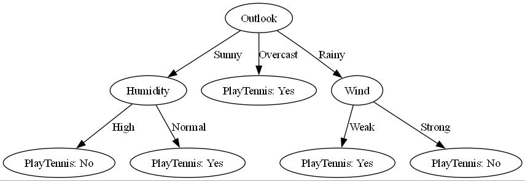

**Picture of PlayTennis Decision Tree Based On Majority Error**

## 2b. Decision Tree using Gini Index

$$GI(Y) = 1 - (p_+^2 + p_-^2)$$
$$GI(Y) = 1 - ((\frac{9}{14})^2 + (\frac{5}{14})^2) = 1 - \frac{106}{196}
= \frac{90}{196} = .46$$

##### Step ii. GI for Each Attribute

##### **Outlook**

When Outlook = Sunny, PlayTennis = [-,-,-,+,+] GI(Outlook = Sunny) = 1 - $(\frac{3}{5})^2$ + $(\frac{2}{5})^2$ = 1 - $\frac{13}{25}$ = $(\frac{12}{25})$

When Outlook = Overcast, PlayTennis = [+,+,+,+] GI(Outlook = Overcast) = 1 - $(\frac{4}{4})^2$ + $(\frac{0}{0})^2$ = 1 - 1 = 0

When Outlook = Rainy, PlayTennis = [+,+,-,+,-] GI(Outlook = Rainy) = 1 - $(\frac{3}{5})^2$ + $(\frac{2}{5})^2$ = 1 - $\frac{13}{25}$ = $(\frac{12}{25})$

$$GI(Outlook) = \frac{5}{14} \cdot \frac{12}{25} + \frac{4}{14} \cdot 0 +
\frac{5}{14} \cdot \frac{12}{25} = \frac{24}{70} = .342$$

##### **Temperature**

When Temperature = Hot, Playtennis = [-,-,+,+] GI(Temperature = Hot) = 1 - $(\frac{1}{2}) ^2$ + $(\frac{1}{2}) ^2$ = 1 - $(\frac{1}{2})$ = $(\frac{1}{2})$

When Temperature = Medium, Playtennis = [+,-,+,+,+,-] GI(Temperature = Medium) = 1 - $(\frac{4}{6}) ^2$ + $(\frac{2}{6}) ^2$ = 1 - $(\frac{20}{36})$ = $(\frac{16}{36})$

When Temperature = Cool, Playtennis = [+,-,+,+] GI(Temperature = Hot) = 1 - $(\frac{3}{4}) ^2$ + $(\frac{1}{4}) ^2$ = 1 - $(\frac{10}{16})$ = $(\frac{6}{16})$

$$GI(Temperature) = \frac{4}{14} \cdot \frac{1}{2} + \frac{6}{14} \cdot
\frac{16}{36} + \frac{4}{14} \cdot \frac{6}{16} = .44$$

#### **Humidity**

When Humidity = High, Playtennis = [-,-,+,+,-,+,-] GI(Humidity = High) = 1 - $(\frac{3}{7}) ^2$ + $(\frac{4}{7}) ^2$ = 1 - $(\frac{25}{49})$ = $(\frac{24}{49})$

When Humidity = Normal, Playtennis = [+,-,+,+,+,+,+] GI(Humidity = Normal) = 1 - $(\frac{6}{7}) ^2$ + $(\frac{1}{7}) ^2$ = 1 - $(\frac{37}{49})$ = $(\frac{12}{49})$

$$GI(Humidity) = \frac{7}{14} \cdot \frac{24}{49} + \frac{7}{14} \cdot
\frac{12}{49} = .368$$

#### **Wind**

When Wind = Strong, Playtennis = [-,-,+,+,+,-] GI(Wind = Strong) = 1 - $(\frac{1}{2}) ^2$ + $(\frac{1}{2}) ^2$ = 1 - $(\frac{1}{2})$ = $(\frac{1}{2})$

When Wind = Weak, Playtennis = [-,+,+,+,-,+,+,+] ME(Wind = Weak) = 1 - $(\frac{6}{8}) ^2$ + $(\frac{2}{8}) ^2$ = 1 - $(\frac{40}{64})$ = $(\frac{24}{64})$

$$GI(Wind) = \frac{6}{14} \cdot \frac{1}{2} + \frac{8}{14} \cdot
\frac{24}{64} = .43$$

##### **Outlook has the Smallest Gini Index, so we will split on Outlook**

### Branch 1. Outlook = Sunny

##### **Humidity**

Given Outlook = Sunny:

When Humidity = High PlayTennis = [-,-,-], GI(Humidity = High | O=S) = 1 - $(\frac{0}{0}) ^2$ + $(\frac{3}{3}) ^2$ = 1 - 1 = 0

When Humidity = Normal PlayTennis = [+,+], GI(Humidity = High | O=S) = 1 - $(\frac{2}{2}) ^2$ + $(\frac{0}{0}) ^2$ = 1 - 1 = 0

$$Gini\text{(Humidity | Outlook = Sunny)} = \frac{3}{5} \times 0 +
\frac{2}{5} \times 0 = 0$$

$$IG\text{(Humidity | Outlook = Sunny)} = 0.48 - 0 = 0.48$$

### Branch 2. Outlook = Overcast

Give Outlook = Rainy, the Gini Index is 1 - 1 - $(\frac{4}{4}) ^2$ + $(\frac{0}{0}) ^2$ = 1 - 1 = 0

**Thus this node is pure and can we can create a leaf node. Given Outlook = Overcast, Playtennis = +**

### Branch 3. Outlook = Rainy

Give Outlook = Rainy, the Majority Error = 1 - $\frac{3}{5}$ = $\frac{2}{5}$

##### **Wind**

Given Outlook = Rainy , when Wind = Weak, Playtennis = [+,+,+] ME(W=W|O=R) = 1 - $\frac{3}{3}$ = 0

Given Outlook = Rainy , when Wind = Strong, Playtennis = [-,-] ME(W=W|O=R) = 1 - $\frac{2}{2}$ = 0

$$IG\text{(Wind| O = R) } = \frac{2}{5} - ((\frac{3}{3} \cdot 0) +
(\frac{2}{2} \cdot 0 ) = \frac{2}{5} - 0 = \frac{2}{5}$$

##### **Wind**

Given Outlook = Rainy:

When Wind = Strong PlayTennis = [-,-], GI(Wind = Strong | O=R) = 1 - $(\frac{0}{2})^2 + (\frac{2}{2})^2$ = 1 - 1 = 0

When Wind = Weak PlayTennis = [+,+,+], GI(Wind = Weak | O=R) = 1 - $(\frac{3}{3})^2 + (\frac{0}{3})^2$ = 1 - 1 = 0

$$Gini\text{(Wind | Outlook = Rainy)} = \frac{2}{5} \times 0 + \frac{3}{5}
\times 0 = 0$$

$$IG\text{(Wind | Outlook = Rainy)} = 0.48 - 0 = 0.48$$
**Thus this node is pure and can we can create a leaf node. Given Outlook = Rainy, When Windy = Weak Playtennis = +, and wehn Windy = Strong Playtennis = -**

This tree will be the same as the Majority Error Tree.

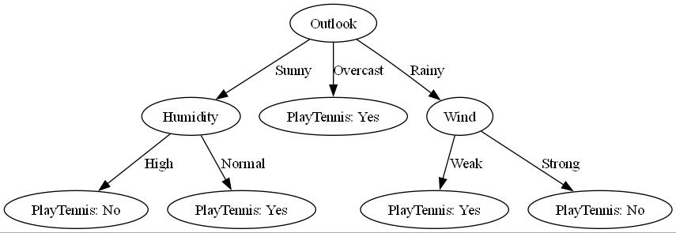

**PlayTennis Decision Tree Based On Gini Index**

## 2C. Decision Tree Similarity

All 3 Decision Trees are the same. Some reasons include that we are training on the same subset of training data, ME and GI are both methods to mathematically choose the best feature to split on and got similar results, and I handled ties the same. For the ME tree, there was a tie between Outlook and Humidity, but I decided to split on Outlook rather than Humidity, but I could’ve made a different tree.

## Problem 3

### 3.a Impute NA Value Based On Most Common Value

Most common Outlook Value is Sunny and Rain, I will impute the missing Value with Sunny.

New Dataset:

$$\begin{array}{|c|c|c|c|c|}
\hline
\text{Outlook} & \text{Temperature} & \text{Humidity} &
\text{Wind} & \text{PlayTennis} \\
\hline
\text{S} & \text{H} & \text{H} & \text{W} & - \\
\text{S} & \text{H} & \text{H} & \text{S} & - \\
\text{O} & \text{H} & \text{H} & \text{W} & + \\
\text{R} & \text{M} & \text{H} & \text{W} & + \\
\text{R} & \text{C} & \text{N} & \text{W} & + \\
\text{R} & \text{C} & \text{N} & \text{S} & - \\
\text{O} & \text{C} & \text{N} & \text{S} & + \\
\text{S} & \text{M} & \text{H} & \text{W} & - \\
\text{S} & \text{C} & \text{N} & \text{W} & + \\
\text{R} & \text{M} & \text{N} & \text{W} & + \\
\text{S} & \text{M} & \text{N} & \text{S} & + \\
\text{O} & \text{M} & \text{H} & \text{S} & + \\
\text{O} & \text{H} & \text{N} & \text{W} & + \\
\text{R} & \text{M} & \text{H} & \text{S} & - \\
\textbf{S} & \textbf{M} & \textbf{N} & \textbf{W} &
\textbf{+} \\
\hline
\end{array}$$

$$\text{Entropy(Y) } = -(\frac{10}{15} \log_2{(\frac{10}{15})} +
\frac{5}{15} \log_2{(\frac{5}{15})}) = .918$$

#### **3a.ii. Attribute Entropy Values and Information Gain**

##### **Outlook**

$$\text{Entropy(Outlook = Sunny) } = -(\frac{1}{2} \log_2{(\frac{1}{2})} +
\frac{1}{2} \log_2{(\frac{1}{2})}) = 1$$
$$\text{Entropy(Outlook = Overcast) } = -(\frac{4}{4}
\log_2{(\frac{4}{4})} + \frac{0}{0} \log_2{(\frac{0}{0})}) = 0$$
$$\text{Entropy(Outlook = Rainy) } = -(\frac{3}{5} \log_2{(\frac{3}{5})} +
\frac{2}{5} \log_2{(\frac{2}{5})}) = .971$$
$$\text{Entropy(Outlook)} = \frac{6}{15} \cdot 1 + \frac{4}{15} \cdot 0 +
\frac{5}{15} \cdot .971 \approx .723$$
$$\textbf{IG(Outlook) }= .918 - .723 = \textbf{.195}$$

##### **Humidity**

$$\text{Entropy(Humidity = High) } = -(\frac{3}{7} \log_2{(\frac{3}{7})} +
\frac{4}{7} \log_2{(\frac{4}{7})}) = .985$$
$$\text{Entropy(Humidity = Normal) } = -(\frac{7}{8} \log_2{(\frac{7}{8})}
+ \frac{1}{8} \log_2{(\frac{1}{8})}) = .543$$
$$\text{Entropy(Humidity)} = \frac{7}{15} \cdot .985 + \frac{8}{15} \cdot
.543 \approx .749$$
$$\textbf{IG(Humidity) }= .918 - .749 = \textbf{.169}$$

##### **Wind**

$$\text{Entropy(Wind = Strong) } = -(\frac{1}{2} \log_2{(\frac{1}{2})} +
\frac{1}{2} \log_2{(\frac{1}{2})}) = 1$$
$$\text{Entropy(Wind = Weak) } = -(\frac{7}{9} \log_2{(\frac{7}{9})} +
\frac{2}{9} \log_2{(\frac{2}{9})}) = .764$$
$$\text{Entropy(Wind)} = \frac{6}{15} \cdot 1 + \frac{9}{15} \cdot
.764 \approx .858$$
$$\textbf{IG(Wind) }= .918 - .858 = \textbf{.06}$$

#### **Based on Entropy, the best attribute to split on is Outlook**

## 3b. Impute NA Value Based On Most Common Among Label

Among Positive labels, the most common value for Outlook is Overcast

$$\begin{array}{|c|c|c|c|c|}
\hline
\text{Outlook} & \text{Temperature} & \text{Humidity} &
\text{Wind} & \text{PlayTennis} \\
\hline
\text{S} & \text{H} & \text{H} & \text{W} & - \\
\text{S} & \text{H} & \text{H} & \text{S} & - \\
\text{O} & \text{H} & \text{H} & \text{W} & + \\
\text{R} & \text{M} & \text{H} & \text{W} & + \\
\text{R} & \text{C} & \text{N} & \text{W} & + \\
\text{R} & \text{C} & \text{N} & \text{S} & - \\
\text{O} & \text{C} & \text{N} & \text{S} & + \\
\text{S} & \text{M} & \text{H} & \text{W} & - \\
\text{S} & \text{C} & \text{N} & \text{W} & + \\
\text{R} & \text{M} & \text{N} & \text{W} & + \\
\text{S} & \text{M} & \text{N} & \text{S} & + \\
\text{O} & \text{M} & \text{H} & \text{S} & + \\
\text{O} & \text{H} & \text{N} & \text{W} & + \\
\text{R} & \text{M} & \text{H} & \text{S} & - \\
\textbf{O} & \textbf{M} & \textbf{N} & \textbf{W} &
\textbf{+} \\
\hline
\end{array}$$

The Entropy for this dataset is the same as 3a, **.918**

##### **3b.ii Attribute Entropy and Information Gain**

##### **Outlook**

$$\text{Entropy(Outlook = Sunny) } = -(\frac{2}{5} \log_2{(\frac{2}{5})} +
\frac{3}{5} \log_2{(\frac{3}{5})}) = .971$$
$$\text{Entropy(Outlook = Overcast) } = -(\frac{5}{5}
\log_2{(\frac{5}{5})} + \frac{0}{0} \log_2{(\frac{0}{0})}) = 0$$
$$\text{Entropy(Outlook = Rainy) } = -(\frac{3}{5} \log_2{(\frac{3}{5})} +
\frac{2}{5} \log_2{(\frac{2}{5})}) = .971$$
$$\text{Entropy(Outlook)} = \frac{5}{15} \cdot .971 + \frac{5}{15} \cdot 0
+ \frac{5}{15} \cdot .971 \approx .647$$
$$\textbf{IG(Outlook) }= .918 - .647 = \textbf{.271}$$

##### Temperature Entropy and Information Gain will be the same here as in 3a. **IG = .017**

##### Humidity Entropy and Information Gain will be the same here as in 3a. **IG = .169**

##### Wind Entropy and Information Gain will be the same here as in 3a. **IG = .06**

#### **Thus, the highest Information Gain is still Outlook, which actually increased from 3a**

## 3C. Impute NA Value Based On Fractional Counts

$$\begin{array}{|c|c|c|c|c|}
\hline
\text{Outlook} & \text{Temperature} & \text{Humidity} &
\text{Wind} & \text{PlayTennis} \\
\hline
\text{S} & \text{H} & \text{H} & \text{W} & - \\
\text{S} & \text{H} & \text{H} & \text{S} & - \\
\text{O} & \text{H} & \text{H} & \text{W} & + \\
\text{R} & \text{M} & \text{H} & \text{W} & + \\
\text{R} & \text{C} & \text{N} & \text{W} & + \\
\text{R} & \text{C} & \text{N} & \text{S} & - \\
\text{O} & \text{C} & \text{N} & \text{S} & + \\
\text{S} & \text{M} & \text{H} & \text{W} & - \\
\text{S} & \text{C} & \text{N} & \text{W} & + \\
\text{R} & \text{M} & \text{N} & \text{W} & + \\
\text{S} & \text{M} & \text{N} & \text{S} & + \\
\text{O} & \text{M} & \text{H} & \text{S} & + \\
\text{O} & \text{H} & \text{N} & \text{W} & + \\
\text{R} & \text{M} & \text{H} & \text{S} & - \\
\textbf{NA} & \textbf{M} & \textbf{N} & \textbf{W} &
\textbf{+} \\
\hline
\end{array}$$

#### 3c.i Entropy

$$Entropy(Y) = -(\frac{9}{14} \log_2 \frac{9}{14} + \frac{5}{14} \log_2
\frac{5}{14}) = \textbf{.94}$$

#### 3c.ii Attribute Entropy

##### **Outlook**

Because we know that the label is positive, we add to the positive label count, and the total size increase as well.

**Outlook = Sunny**

Positive Label = 2 + $\frac{5}{14}$ = $\frac{33}{14}$ Negative Label = 3 Size = 5 + $\frac{5}{14}$ = $\frac{75}{14}$

$$\text{Entropy(Sunny) }= -(\frac{\frac{33}{14}}{\frac{75}{14}} \cdot
\log_2(\frac{\frac{33}{14}}{\frac{75}{14}}) + \frac{3}{\frac{75}{14}}
\cdot \log_2 (\frac{3}{\frac{75}{14}})) = .989$$

**Outlook = Overcast**

Positive Label = 4 + $\frac{4}{14}$ = $\frac{60}{14}$ Negative Label = 0 Size = 4 + $\frac{4}{14}$ = $\frac{60}{14}$

$$\text{Entropy(Overcast) }= 0$$
**Outlook = Rainy**

Positive Label = 3 + $\frac{5}{14}$ = $\frac{47}{14}$ Negative Label = 2 Size = 5 + $\frac{5}{14}$ = $\frac{75}{14}$

$$\text{Entropy(Rainy) }= -(\frac{\frac{47}{14}}{\frac{75}{14}} \cdot
\log_2(\frac{\frac{47}{14}}{\frac{75}{14}}) + \frac{2}{\frac{75}{14}}
\cdot \log_2 (\frac{2}{\frac{75}{14}})) = .953$$

$$\text{Entropy(Outlook) }= \frac{5}{14} \cdot .989 + \frac{5}{14} \cdot
.953 = \textbf{.694}$$
$$IG(Outlook) = .94 - .694 = \textbf{.246}$$
**Temperature**

**Temperature = Hot**

Positive Label = 2 + $\frac{4}{14}$ = $\frac{32}{14}$ Negative Label = 2 Size = 4 + $\frac{4}{14}$ = $\frac{60}{14}$

$$\text{Entropy(Hot) }= -(\frac{\frac{32}{14}}{\frac{60}{14}} \cdot
\log_2(\frac{\frac{32}{14}}{\frac{60}{14}}) + \frac{2}{\frac{60}{14}}
\cdot \log_2 (\frac{2}{\frac{60}{14}})) = .997$$
**Temperature = Medium**

Positive Label = 4 + $\frac{6}{14}$ = $\frac{62}{14}$ Negative Label = 2 Size = 6 + $\frac{6}{14}$ = $\frac{90}{14}$

$$\text{Entropy(Medium) }= -(\frac{\frac{62}{14}}{\frac{90}{14}} \cdot
\log_2(\frac{\frac{62}{14}}{\frac{90}{14}}) + \frac{2}{\frac{90}{14}}
\cdot \log_2 (\frac{2}{\frac{90}{14}})) = .894$$

**Temperature = Cold**

Positive Label = 3 + $\frac{4}{14}$ = $\frac{46}{14}$ Negative Label = 1 Size = 6 + $\frac{4}{14}$ = $\frac{84}{14}$

$$\text{Entropy(Medium) }= -(\frac{\frac{46}{14}}{\frac{84}{14}} \cdot
\log_2(\frac{\frac{46}{14}}{\frac{84}{14}}) + \frac{1}{\frac{84}{14}}
\cdot \log_2 (\frac{1}{\frac{84}{14}})) = .907$$
$$\text{Entropy(Temperature) }= \frac{4}{14} \cdot .997 + \frac{6}{14}
\cdot .894 + \frac{4}{14} \cdot .907 = \textbf{.927}$$
$$IG(Temperature) = .94 - .927 = \textbf{.013}$$
**Humidity**

**Humidity = High**

Positive Label = 3 + $\frac{7}{14}$ = $\frac{49}{14}$ Negative Label = 4 Size = 7 + $\frac{7}{14}$ = $\frac{105}{14}$

**Humidity = Normal**

Positive Label = 6 + $\frac{7}{14}$ = $\frac{91}{14}$ Negative Label = 1 Size = 7 + $\frac{7}{14}$ = $\frac{105}{14}$

$$\text{Entropy(Normal) }= -(\frac{\frac{91}{14}}{\frac{105}{14}} \cdot
\log_2(\frac{\frac{91}{14}}{\frac{105}{14}}) + \frac{1}{\frac{105}{14}}
\cdot \log_2 (\frac{1}{\frac{105}{14}})) = .567$$
$$\text{Entropy(Humidity) }= \frac{7}{14} \cdot .606 + \frac{7}{14} \cdot
.567 = \textbf{.5865}$$
$$IG(Humidity) = .94 - .5865 = \textbf{.3535}$$

**Wind**

**Wind = Strong**

Positive Label = 3 + $\frac{6}{14}$ = $\frac{48}{14}$ Negative Label = 3 Size = 6 + $\frac{6}{14}$ = $\frac{90}{14}$

$$\text{Entropy(Strong) }= -(\frac{\frac{48}{14}}{\frac{90}{14}} \cdot
\log_2(\frac{\frac{48}{14}}{\frac{90}{14}}) + \frac{3}{\frac{90}{14}}
\cdot \log_2 (\frac{3}{\frac{90}{14}})) = .997$$
**Wind = Weak**

Positive Label = 6 + $\frac{8}{14}$ = $\frac{92}{14}$ Negative Label = 2 Size = 8 + $\frac{8}{14}$ = $\frac{120}{14}$

$$\text{Entropy(Strong) }= -(\frac{\frac{92}{14}}{\frac{120}{14}} \cdot
\log_2(\frac{\frac{92}{14}}{\frac{120}{14}}) + \frac{2}{\frac{120}{14}}
\cdot \log_2 (\frac{2}{\frac{120}{14}})) = .784$$
$$\text{Entropy(Wind) }= \frac{6}{14} \cdot .997 + \frac{8}{14} \cdot
.784 = \textbf{.875}$$
$$IG(Wind) = .94 - .875 = \textbf{.065}$$

## 4. Prove that Information Gain is Always Non-Negative

### Entropy

The entropy of a dataset $S$ is defined as:

$$H(S) = - \sum_{i=1}^{k} p_i \log(p_i)$$

where $p_i$ is the proportion of instances in class $i$ in $S$, and $k$ is the number of classes.

### Information Gain

Information Gain for an attribute $A$ is defined as:

$$IG(S, A) = H(S) - \sum_{v \in \text{values}(A)} \frac{|S_v|}{|S|} H(S_v)$$

where $S_v$ is the subset where $A$ takes value $v$, and $\frac{|S_v|}{|S|}$ is the proportion of elements in $S_v$.

### Proof

Entropy $H$ is concave, meaning the weighted average entropy of subsets is less than or equal to the entropy of the whole set:

$$H(S) \geq \sum_{v \in \text{values}(A)} \frac{|S_v|}{|S|} H(S_v)$$

Thus, Information Gain is:

$$IG(S, A) = H(S) - \sum_{v \in \text{values}(A)} \frac{|S_v|}{|S|} H(S_v)
\geq 0$$

### Conclusion

Since splitting the data reduces or maintains entropy, Information Gain is always nonnegative.

## 5. Regression Tree Gain

Because this is a Regression problem, we want to minimize the variance in the tree’s predictions. We can use the Information Gain formula but replace entropy with variance.

$$Var(Y) = \frac{1}{n}\sum_i^n(y_i - \hat{y} )^2$$

After splitting, calculate the variance of the target variable within each split (subset of data) and weight it by the proportion of data points in that split:

$$Var(Attribute) = \sum_i^k \frac{N_k}{N}Var(Y_k)$$
K is the number of subsets after the split (for continuous variables, this could be binary splits, while for categorical variables, it could be more).

N_k is the number of data points in the k-th subset.

Var(Y_k) is the variance of the target values in the k-th subset.

$$IG(Y,k) = Var(Y) - \sum_i^k \frac{N_k}{N}Var(Y_k)$$

**You would want to choose the Attribute that outputs the highest IG value to split on that attribute**